# Urbanization and Public Transportation of Los Angeles

Kainoa Kanter, Julian Jacobson, Aidan Allen

November 29, 2023

Abstract

This paper will examine how Los Angeles’s demand for public transportation has been affected the last few years, utilizing derivatives to determine the rate of change in public transportation usage.

# Introduction

Los Angeles – the sprawling metropolis that we call home – has become synonymous with both opportunity and urban challenges and has experienced rapid growth in recent decades. This growth has significant implications for various sectors, particularly the public transportation system. As one of the most car-dependent cities in the United States, Los Angeles faces unique challenges in scaling its public transportation network to meet increasing demand. Understanding the dynamics of public transportation usage and the factors influencing ridership is critical for planning and policy development.

The aim of this study is to examine how the rapid growth of Los Angeles affects the demand for public transportation. The investigation includes a quantitative assessment utilizing derivatives to determine the rate of change in public transportation usage. This analysis offers insights into the responsiveness of ridership to changes in these factors, informing strategies to enhance the public transportation system.

This information can be useful for making impactful decisions related to resource allocation, service expansion, and policy adjustments. Transit agencies can use this information to optimize fare structures, implement dynamic pricing models, or introduce discounts and incentives to attract more riders during specific times or for particular modes. Additionally, knowing how pricing, availability, and convenience impact ridership allows for targeted marketing and communication strategies.

## Methodology

### Data Collection

The methodological approach consists of two primary quantitative analyses:

#### Rate of Change Analysis:

- Utilize time-series data to calculate the first derivative of ridership numbers, yielding the rate of change over the years. This derivative analysis will be conducted separately for bus and rail services, offering a granular view of usage trends.
- Data transformation into a suitable format for analysis using the tidyverse collection of R packages.
- Visualization of trends through line plots, elucidating patterns and growth trajectories.

#### Visualization

- Data visualization was implemented using the `ggplot2` package in R
- Line plots were created to illustrate the trends in public transportation ridership over time, broken down by transportation type (bus and rail)
- Adjustments were made to display actual numbers instead of scientific notation for clarity

# Exploratory Data Analysis

As seen in the graph below, ridership data for both the Metro Bus system and Metro Light Rail between 2019 and 2023 has been heavily impacted by the 2020 pandemic. The bus ridership has had more of a sharp decline from 2019 to 2020 and bounce-back shortly, while the rail was slowing down from 2019 - 2021, with not a lot of recovery.

[figure not shown]

# Derivative Analysis

The rate of change in public transportation usage offers valuable insights into trends and can help forecast future demand. By differentiating the ridership data with respect to time, we can obtain the instantaneous rate of change, which is expressed mathematically as:

$$R'(t) = \frac{dR}{dt}$$

where $R(t)$ represents the ridership at time $t$. This derivative analysis provides the velocity of ridership change, indicating whether usage is increasing or decreasing over time.

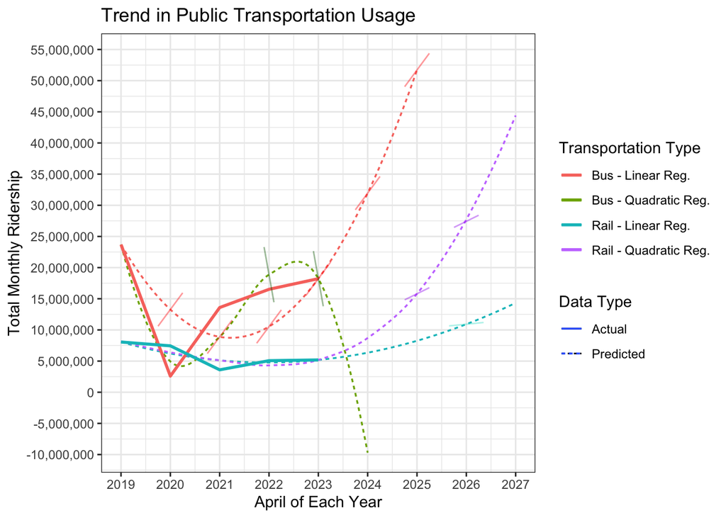

Line plot of public transportation ridership over time with regression lines

## Conclusion

Firstly, an improved understanding of the allocation of resources and labor is something that decision makers within the public transportation sector can take away from our analysis. Understanding the rate of change helps city planners anticipate changes in transportation preferences and adjust infrastructure investments accordingly. On the projects page of the metro website (https://www.metro.net/projects/), there are dozens of various projects that each require valuable tax-dollars, time, resources, planning, and execution. As Los Angeles is the third largest metropolitan area by GDP, being efficient in its decision making surrounding the allocation of resources in all facets of public transportation is something that our analysis of the rate of change of the bus and rail ridership over a five-year period will help better inform.

As anyone who has been to Los Angeles knows the horror stories of its infamous traffic, our analysis of the rate of change for transportation options in Los Angeles can guide policies aimed at managing traffic congestion, an example of such being incentives for alternative transportation modes. As transportation is a significant contributor to air pollution and greenhouse gas emissions, understanding how demand for different transportation options impacts the environment can help in designing policies that encourage environmentally friendly modes of transportation, such as public transit or electric vehicles. In a more economic sense, the transportation sector is closely tied to the overall economy. Understanding the rate of change can provide insights into the economic impact of specific changes in transportation options. This information is valuable for businesses, urban development, and job accessibility.

Overall, an analysis of the data of public transportation in a city like Los Angeles offers immense benefits. From the perspective of the city, having a clearer understanding of the rate of change between transportation modes over a five-year period enables them to make better informed decisions compared to only looking at raw data and trusting government intuition. From a business and entrepreneurial perspective, understanding the historical and predicted demand of various transportation and pricing options allows for entrepreneurs to better understand the institutional voids that may exist in public transportation in Los Angeles, and to potentially develop the next problem solver. (reference proposed Union Station to Dodger Stadium 5,000 seat gondola estimated well over original $300 million estimate ([latimes.com -Dodger Stadium Gondola](https://www.latimes.com/sports/story/2023-04-30/dodger-stadium-gondola-project-frank-mccourt))

# Sources:

- Transit ridership data: Los Angeles Metro “L.A. METRO TRANSIT RIDERSHIP UP 10 PERCENT, SETS POST-PANDEMIC RECORD”, Patrick Chandler
- R Paper source code: https://github.com/thatonecalculator/math-28-project
- https://www.latimes.com/sports/story/2023-04-30/dodger-stadium-gondola-project-frank-mccourt
- https://www.metro.net/projects/